# Psych 254 W15 PS #2

Mike Frank, Natalia Vélez

February 4, 2015

This is problem set #2, in which we hope you will practice the visualization package ggplot2, as well as hone your knowledge of the packages tidyr and dplyr.

# Part 1: Basic intro to ggplot

## Part 1A: Exploring ggplot2 using qplot

Note, that this example is from the_grammar.R on http://had.co.nz/ggplot2 I’ve adapted this for psych 254 purposes

First install and load the package.

```r
library(ggplot2)
library(knitr)
library(pander)
```

Now we’re going to use qplot. qplot is the easy interface, meant to replace plot. You can give it simple `qplot(x,y)` examples, or slightly more complex examples like `qplot(x, y, col=grp, data=d)`.

We’re going to be using the diamonds dataset. This is a set of measurements of diamonds, along with their price etc.

```r
head(diamonds)
```

```
##   carat       cut color clarity depth table price    x    y    z
## 1  0.23     Ideal     E     SI2  61.5    55   326 3.95 3.98 2.43
## 2  0.21   Premium     E     SI1  59.8    61   326 3.89 3.84 2.31
## 3  0.23      Good     E     VS1  56.9    65   327 4.05 4.07 2.31
## 4  0.29   Premium     I     VS2  62.4    58   334 4.20 4.23 2.63
## 5  0.31      Good     J     SI2  63.3    58   335 4.34 4.35 2.75
## 6  0.24 Very Good     J    VVS2  62.8    57   336 3.94 3.96 2.48
```

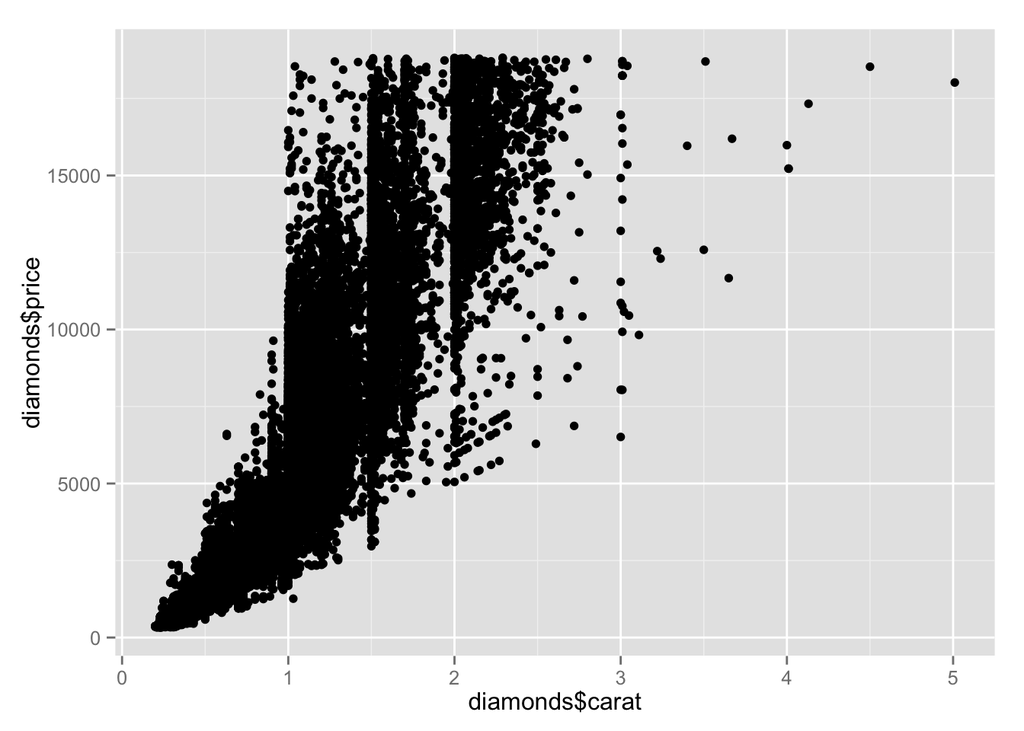

```r
qplot(diamonds$carat, diamonds$price)
```

Scatter plots are trivial, and easy to add features to. Modify this plot so that it uses the dataframe rather than working from variables in the general namespace (good to get away from retyping `diamonds$` every time you reference a variable).

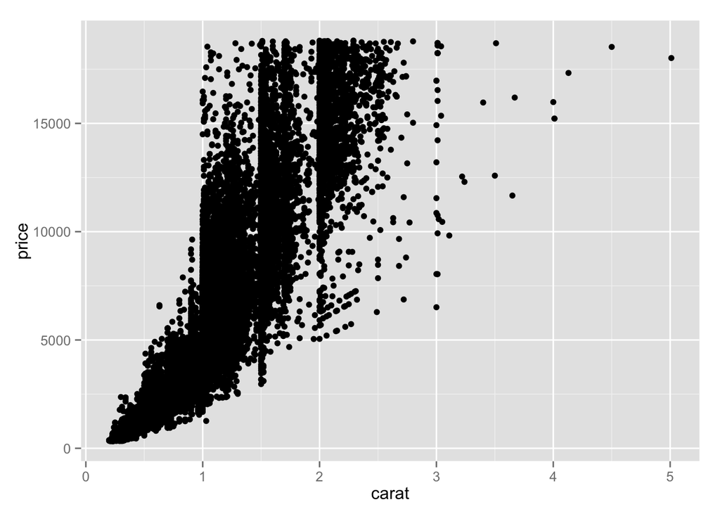

```r
qplot(carat, price, data = diamonds)
```

Try adding clarity and cut, using shape and color as your visual variables.

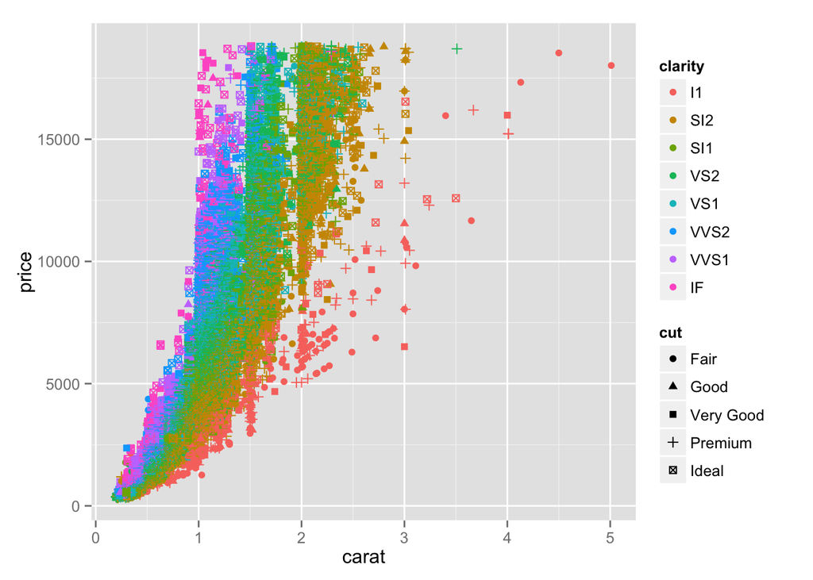

```r
qplot(carat, price, data = diamonds, shape = cut, colour = clarity)
```

One of the primary benefits of `ggplot2` is the use of facets - also known as small multiples in the Tufte vocabulary. That last plot was probably hard to read. Facets could make it better. Try adding a `facets = x ~ y` argument. `x ~ y` means row facets are by x, column facets by y.

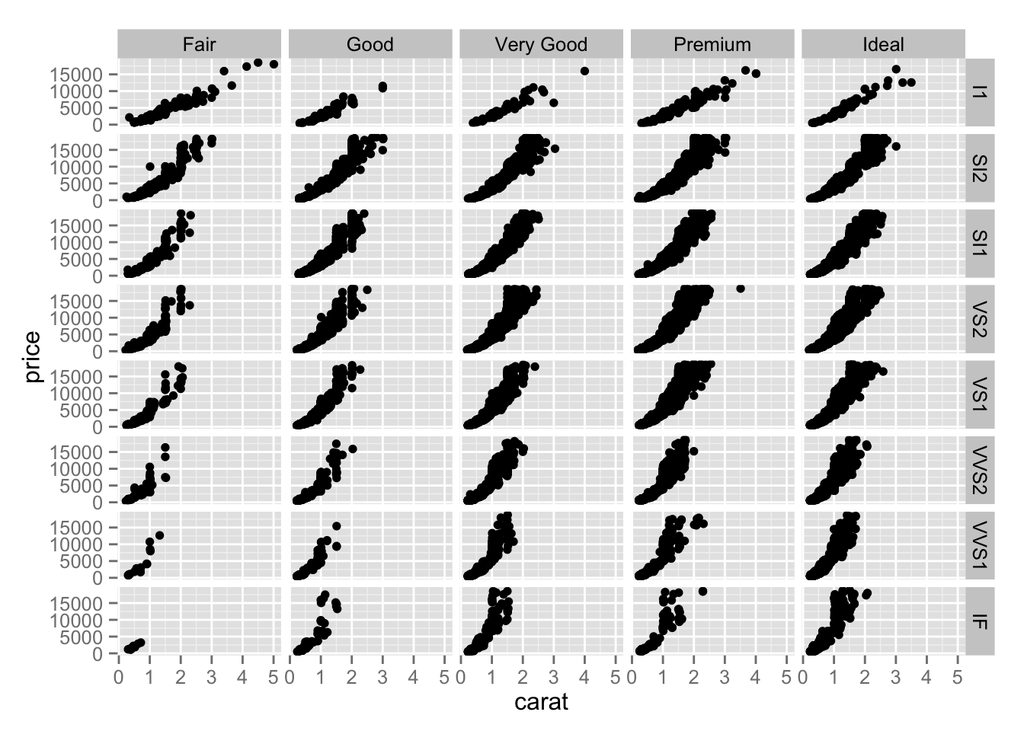

```r
qplot(carat, price, data = diamonds,
      facets = clarity ~ cut)
```

But facets can also get overwhelming. Try to strike a good balance between color, shape, and faceting.

HINT: `facets = . ~ x` puts x on the columns, but `facets = ~ x` (no dot) *wraps* the facets. These are underlying calls to different functions, `facet_wrap` (no dot) and `facet_grid` (two arguments).

Note: I also changed the color scheme to grayscale, with the intuition that brightness maps intuitively to diamond clarity: ‘I1’, the lowest grade, is darkest and ‘IF’, the highest quality grade, is the lightest.

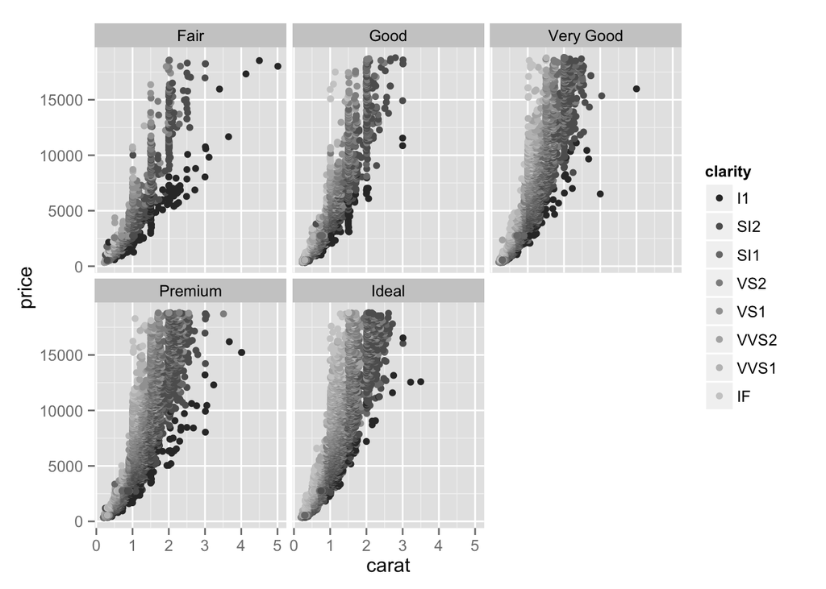

```r
qplot(carat, price, data = diamonds,
      colour = clarity,
      facets = ~ cut) + scale_colour_grey()
```

The basic unit of a ggplot plot is a “geom” - a mapping between data (via an “aesthetic”) and a particular geometric configuration on coordinate axes.

Let’s try some other geoms and manipulate their parameters. First, try a histogram (`geom="hist"`).

```
## stat_bin: binwidth defaulted to range/30. Use 'binwidth = x' to adjust this.
```

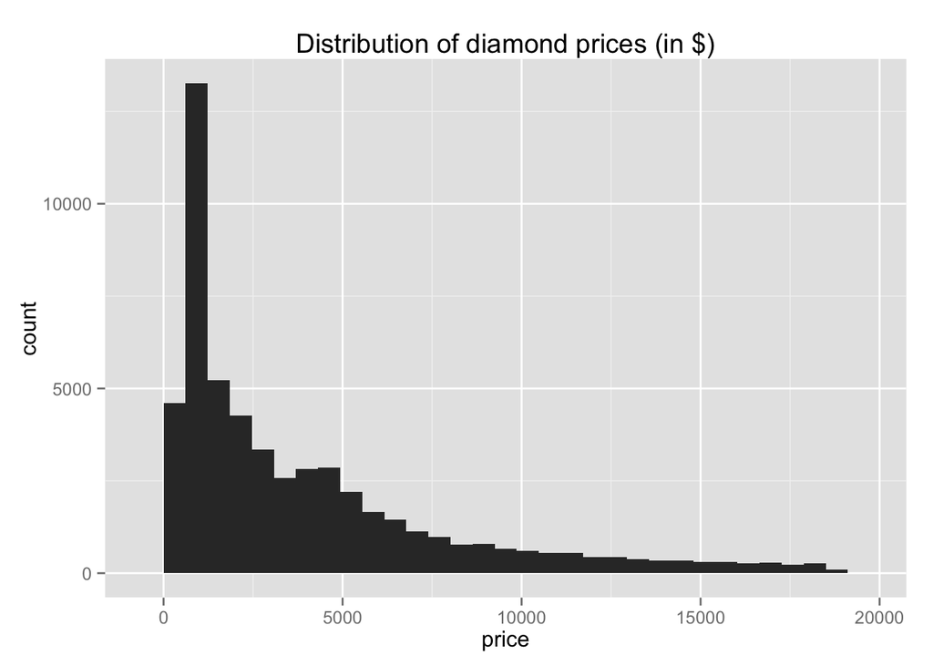

```r
ggplot(diamonds, aes(x = price)) +
  geom_histogram() +
  ggtitle("Distribution of diamond prices (in $)")
```

```
## stat_bin: binwidth defaulted to range/30. Use 'binwidth = x' to adjust this.
```

[figure not shown]

```r
ggplot(diamonds, aes(x = carat)) +
  geom_histogram() +
  ggtitle("Distribution of diamond mass (in carats)")
```

[output not shown]

Now facet your histogram by clarity and cut.

[output not shown]

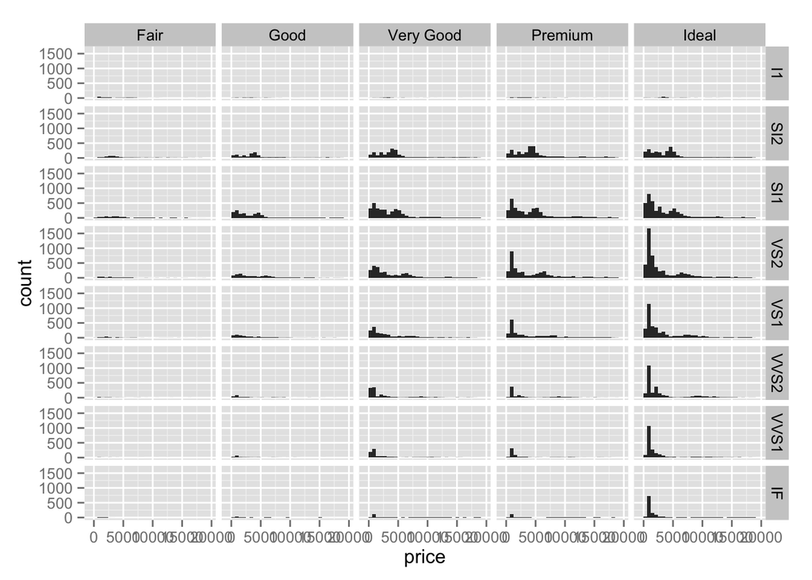

```r
ggplot(diamonds, aes(x = price)) +
  geom_histogram() +
  facet_grid(clarity ~ cut)
```

I like a slightly cleaner look to my plots. Luckily, ggplot allows you to add “themes” to your plots. Try doing the same plot but adding `+ theme_bw()` or `+ theme_classic()`. Different themes work better for different applications, in my experience.

[output not shown]

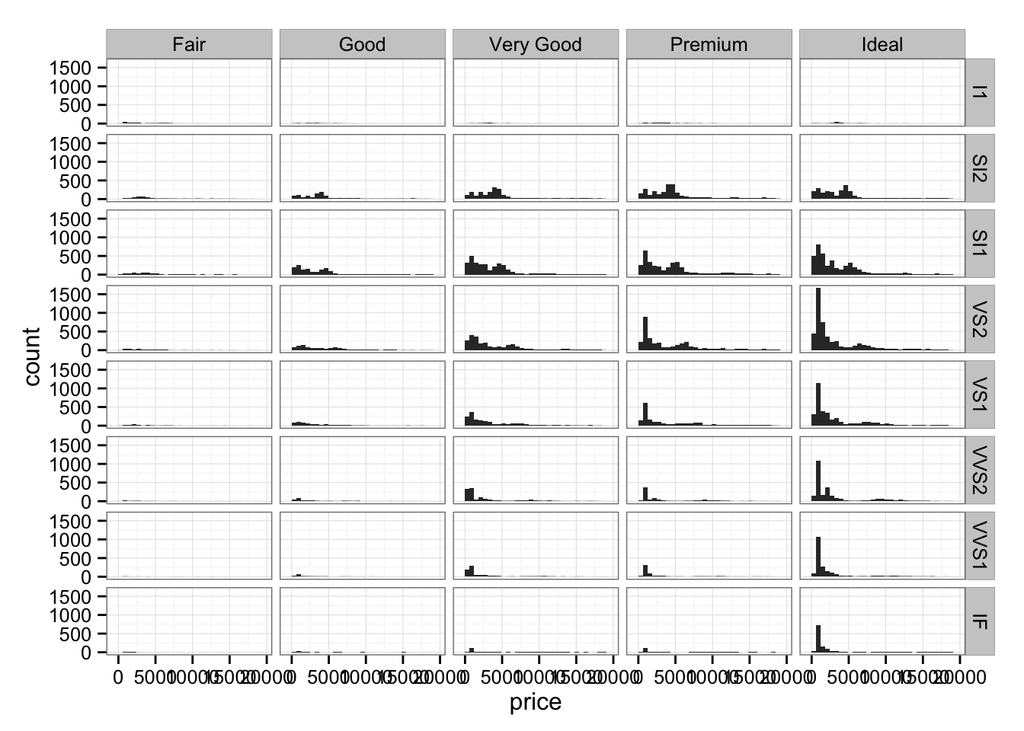

```r
ggplot(diamonds, aes(x = price)) +
  geom_histogram() +
  facet_grid(clarity ~ cut) +
  theme_bw()
```

## Part 1B: Exploring ggplot2 using ggplot

`ggplot` is just a way of building `qplot` calls up more systematically. It’s sometimes easier to use and sometimes a bit more complicated. What I want to show off here is the functionality of being able to build up complex plots with multiple elements. You can actually do this using qplot pretty easily, but there are a few things that are hard to do.

`ggplot` is the basic call, where you specify A) a dataframe and B) an aesthetic mapping from variables in the plot space to variables in the dataset.

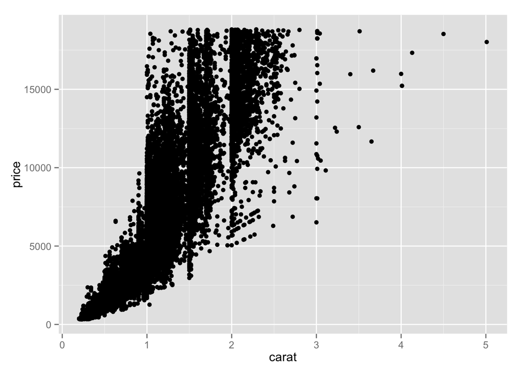

```r
d <- ggplot(diamonds, aes(x=carat, y=price)) # first you set the aesthetic and dataset
d + geom_point() # then you add geoms
```

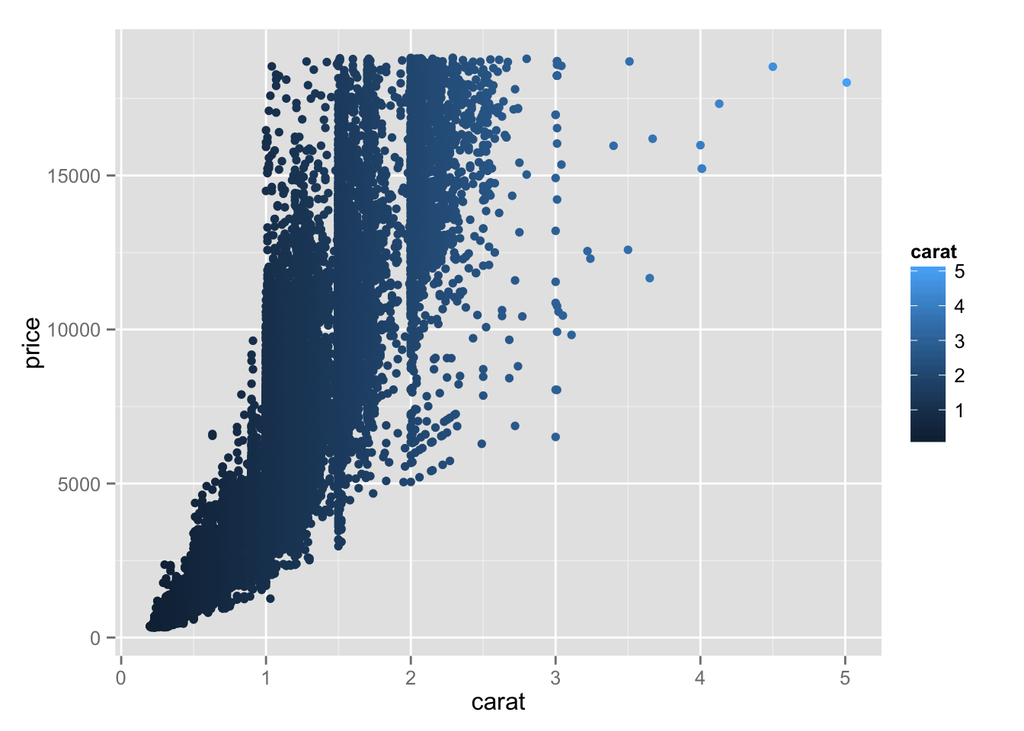

```r
d + geom_point(aes(colour = carat)) # and you can keep doing this to add layers to the plot
```

Try writing this as a single set of additions (e.g. one line of R code, though you can put in linebreaks). This is the most common workflow for me.

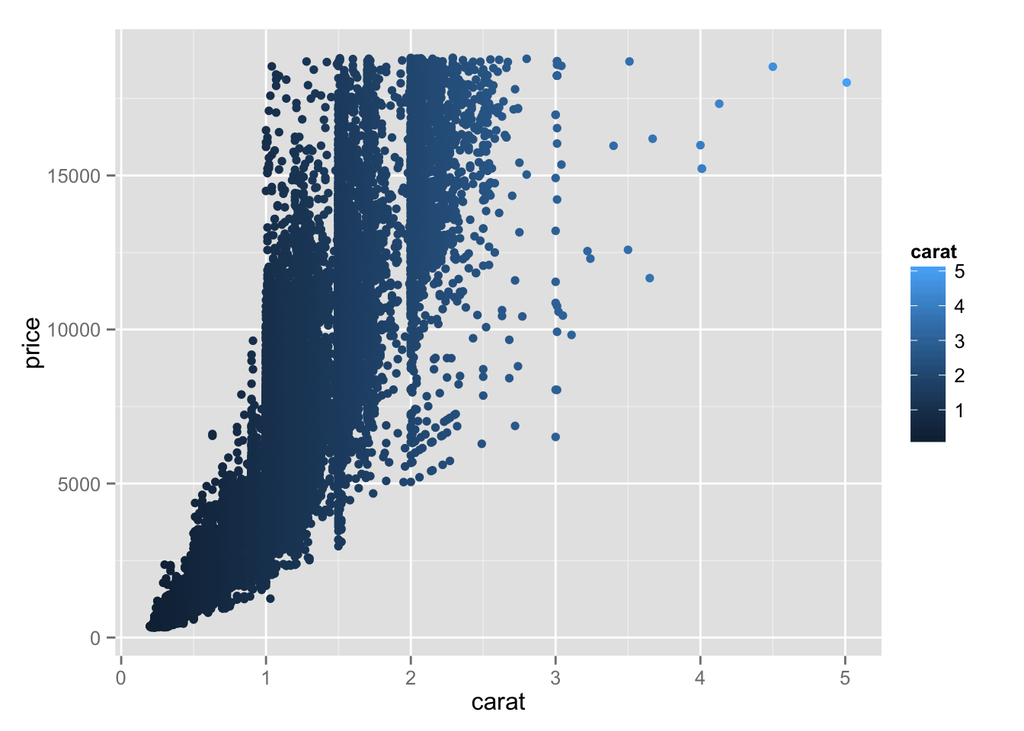

```r
ggplot(diamonds, aes(x=carat, y=price)) +
  geom_point(aes(colour = carat))
```

You can also set the aesthetic separately for each geom, and make some great plots this way. Though this can get complicated. Try using `ggplot` to build a histogram of prices.

```
## stat_bin: binwidth defaulted to range/30. Use 'binwidth = x' to adjust this.
```

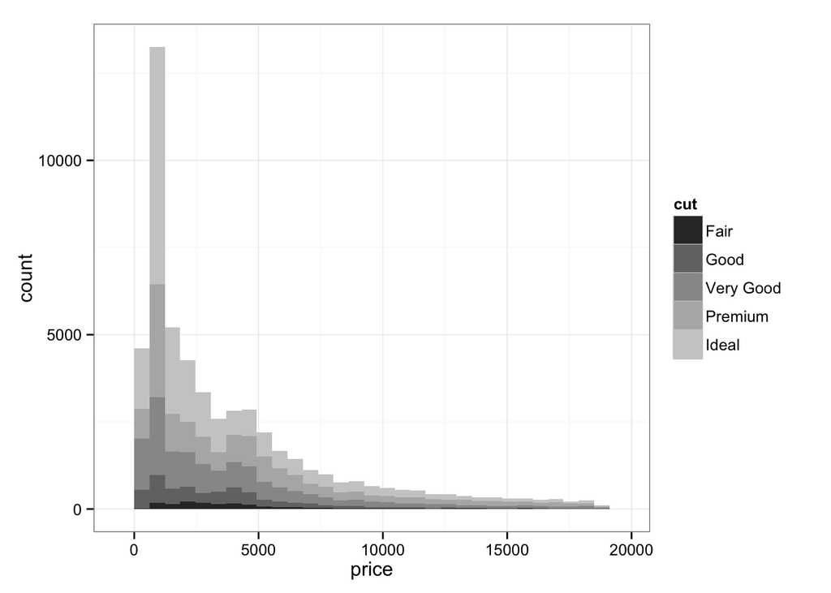

```r
ggplot(diamonds, aes(x=price)) +
  geom_histogram(aes(fill=cut)) +
  scale_fill_grey() +
  theme_bw()
```

# Part 2: Diving into real data: Sklar et al. (2012)

Sklar et al. (2012) claims evidence for unconscious arithmetic processing. We’re going to do a reanalysis of their Experiment 6, which is the primary piece of evidence for that claim. The data are generously contributed by Asael Sklar.

First let’s set up a few preliminaries.

```r
library(tidyr)
library(plyr)
library(dplyr)
```

```r
library(ggplot2)

sem <- function(x) {sd(x) / sqrt(length(x))}
ci95 <- function(x) {sem(x) * 1.96}
```

## Data Prep

First read in two data files and subject info. A and B refer to different trial order counterbalances.

```r
subinfo <- read.csv("../data/sklar_expt6_subinfo_corrected.csv")
d.a <- read.csv("../data/sklar_expt6a_corrected.csv")
d.b <- read.csv("../data/sklar_expt6b_corrected.csv")
```

Gather these datasets into long form and get rid of the Xs in the headers.

```r
da.tidy <- d.a %>%
  gather("subid", "rt", X1:X21) %>%
  select(prime, operand, congruent, distance, counterbalance, subid, rt)
da.tidy$subid <- extract_numeric(da.tidy$subid)

db.tidy <- d.b %>%
  gather("subid", "rt", X22:X42) %>%
  select(prime, operand, congruent, distance, counterbalance, subid, rt)
db.tidy$subid <- extract_numeric(db.tidy$subid)
```

Bind these together. Check out `bind_rows`.

```r
d.tidy <- rbind(da.tidy, db.tidy)
```

Merge these with subject info. You will need to look into merge and its relatives, `left_join` and `right_join`. Call this dataframe `d`, by convention.

```r
d <- left_join(subinfo, d.tidy)
```

Clean up the factor structure.

```r
d$presentation.time <- factor(d$presentation.time)
levels(d$operand) <- c("addition","subtraction")
subinfo$subjective.test <- factor(subinfo$subjective.test, labels=c("False", "True"))
d$subid <- factor(d$subid)
```

## Data Analysis Preliminaries

Examine the basic properties of the dataset. First, take a histogram.

```
## stat_bin: binwidth defaulted to range/30. Use 'binwidth = x' to adjust this.
```

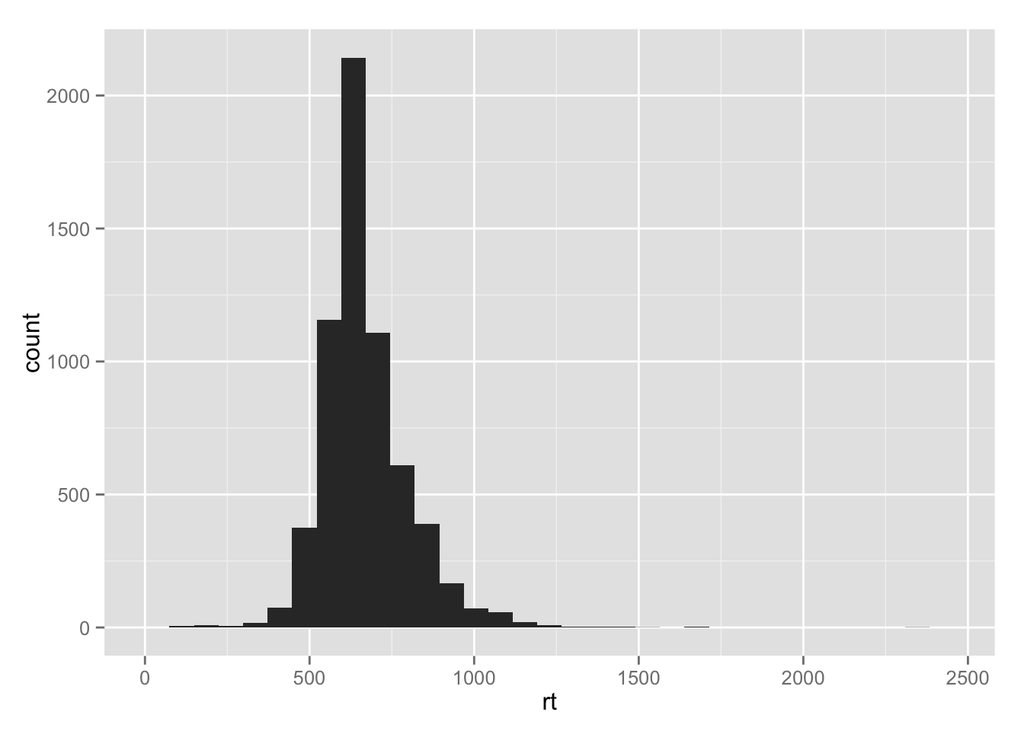

```r
ggplot(d, aes(x = rt)) +
  geom_histogram()
```

Challenge question: what is the sample rate of the input device they are using to gather RTs?

```r
rts <- unique(sort(d$rt))
min(rts[2:length(rts)] - rts[1:length(rts)-1])
```

```
## [1] 1
```

**Answer:** The smallest difference in reaction times that the input device can resolve is 1 msec. Therefore, the sample rate is 1000 Hz.

Sklar et al. did two manipulation checks. Subjective - asking participants whether they saw the primes - and objective - asking them to report the parity of the primes (even or odd) to find out if they could actually read the primes when they tried. Examine both the unconscious and conscious manipulation checks (this information is stored in subinfo). What do you see? Are they related to one another?

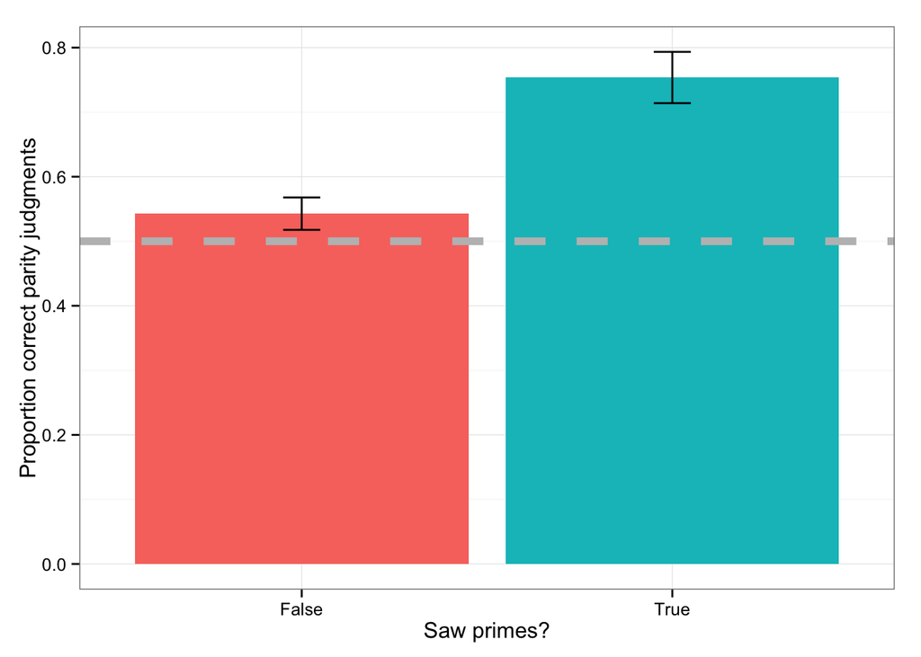

```r
sub.summ <- subinfo %>%
  group_by(subjective.test) %>%
  dplyr::summarise(avg = mean(objective.test),
            sd = sd(objective.test),
            n = length(objective.test),
            se = sem(objective.test))

ggplot(sub.summ, aes(x = subjective.test, y = avg, fill = subjective.test)) +
  geom_bar(stat="identity") +
  geom_errorbar(aes(ymin = avg - se, ymax = avg + se), width = 0.1) +
  geom_abline(intercept = 0.5, slope = 0, colour = "gray", linetype = "dashed",
              size = 2) +
  xlab("Saw primes?") +
  ylab("Proportion correct parity judgments") +
  theme_bw() +
  guides(fill = F)
```

**Conclusion:** Participants who reported that they could see the primes were above chance when judging the parity of the primes (one sample t-test, t(20) = 6.38, p < 0.001). Conversely, participants who couldn’t see the primes were at chance (one sample t-test, t(20) = 1.70, p = 0.10). Therefore, participants who *thought* they could see the primes could actually read them when they tried.

OK, let’s turn back to the measure and implement Sklar et al.’s exclusion criterion. You need to have said you couldn’t see (subjective test) and also be not significantly above chance on the objective test (< .6 correct). Call your new data frame `ds`.

```r
ds <- with(d, d[subjective.test == 0 & objective.test < .6,])
```

## Sklar et al.’s analysis

Sklar et al. show a plot of a “facilitation effect” - the time to respond to incongruent primes minus the time to respond to congruent primes. They then show plot this difference score for the subtraction condition and for the two presentation times they tested. Try to reproduce this analysis.

HINT: first take averages within subjects, then compute your error bars across participants, using the `sem` function (defined above).

```r
d.summ <- ds %>%
  group_by(presentation.time, subid, congruent, operand) %>%
  dplyr::summarise(avg = mean(rt, na.rm = T)) %>%
  ungroup() %>%
  spread(congruent, avg) %>%
  group_by(presentation.time, subid, operand) %>%
  dplyr::summarise(f = mean(no)-mean(yes)) %>%
  group_by(presentation.time, operand, add = F) %>%
  dplyr::summarise(se = sem(f),
                   facilitation = mean(f))

pander(data.frame(d.summ))
```

| presentation.time | operand | se | facilitation |
| --- | --- | --- | --- |
| 1700 | addition | 8.902 | -13.93 |
| 1700 | subtraction | 6.275 | 21 |
| 2000 | addition | 5.022 | 4.026 |
| 2000 | subtraction | 4.447 | 9.976 |

Now plot this summary, giving more or less the bar plot that Sklar et al. gave (though I would keep operation as a variable here. Make sure you get some error bars on there (e.g. `geom_errorbar` or `geom_linerange`).

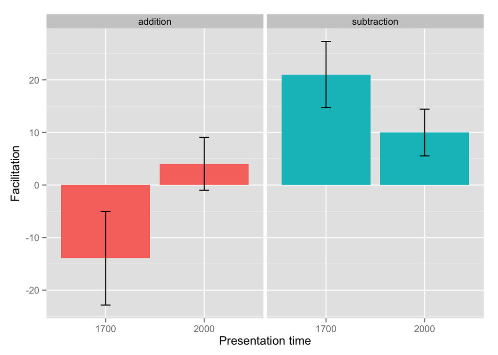

```r
ggplot(d.summ, aes(x = presentation.time, y = facilitation, fill = operand)) +
  geom_bar(stat="identity") +
  geom_errorbar(width = .1, aes(ymin = facilitation - se, ymax = facilitation + se)) +
  facet_grid(. ~ operand) +
  guides(fill = F) +
  xlab("Presentation time") +
  ylab("Facilitation")
```

What do you see here? How close is it to what Sklar et al. report? Do the error bars match? How do you interpret these data?

There are two notable differences between this plot and Sklar et al’s report:

1. Sklar et al. omit data for addition trials because there was no effect of priming in this condition (P > 0.33). The authors’ justify this decision by reasoning that “because addition is easier and solved faster, the solutions of the addition equations had already decayed when the targets appeared on screen.”
2. The error bars shown in Sklar et al.’s report denote values *within 1 standard error* of the mean. Here, error bars denote $\pm 1$ standard error of the mean, which is the more common usage.

From these data, it seems that, indeed, showing participants CFS-masked equations of *added* numbers does not prime them to identify the correct answer faster (e.g., showing ‘1+3+5’ does not facilitate identification of ‘9’). Regardless of presentation time, participant’s scores during congruent trials were not significantly faster than their reactions during incongruent trials—that is, their ‘facilitation’ score was not different from 0. Conversely, both groups of participants showed priming in the subtraction trials, regardless of presentation time. These results lend support to the authors’ claim that subliminally presented arithmetic expressions, which are widely believed to require consciousness to be evaluated, prime participants’ identification of numbers.

Challenge problem: verify Sklar et al.’s claim about the relationship between RT and the objective manipulation check.

## Your own analysis

Show us what you would do with these data, operating from first principles. What’s the fairest plot showing a test of Sklar et al.’s original hypothesis that people can do arithmetic “non-consciously”?

In the original analysis, Sklar et al. test whether the mean facilitation score (i.e., mean RT on incongruent trials - mean RT on congruent trials) was different from 0. However, difference scores suffer from a host of methodological problems: for example, they are less reliable than their component variables, its variance increases with its value, and they hide correlations between measures (for an overview, see Peter et al., 1993).

Another, potentially more reliable test of their claim is to compare participants’ reaction time on congruent and incongruent trials. If people can do arithmetic non-consciously, then they should be faster to respond on congruent trials than incongruent trials. According to Sklar et al.’s original results, we should only find this effect on subtraction trials. (Subseqent experiments in Sklar et al.’s original result help resolve why there is no facilitation on addition trials, but we will ignore this issue here.)

**References:** Peter, J. P., Churchill Jr, G. A., & Brown, T. J. (1993). Caution in the use of difference scores in consumer research. *Journal of consumer research,* 655-662.

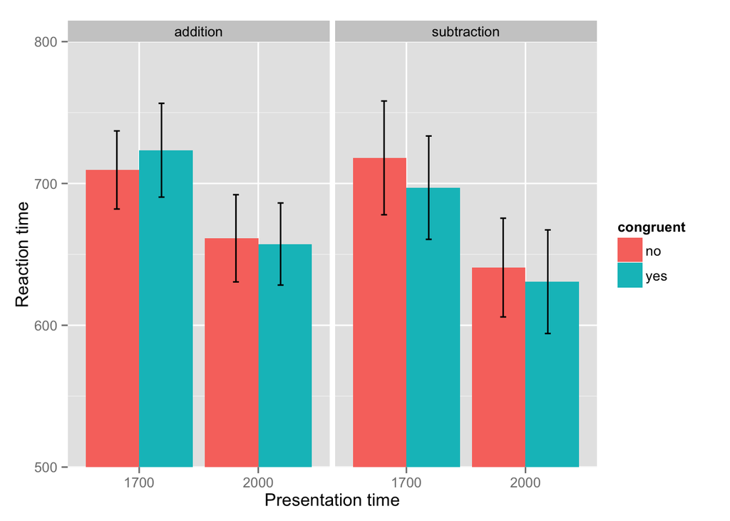

```r
d.summ2 <- ds %>%
  group_by(presentation.time, subid, congruent, operand) %>%
  dplyr::summarise(avg = mean(rt, na.rm = T)) %>%
  group_by(presentation.time, congruent, operand) %>%
  dplyr::summarize(rt = mean(avg),
                   se = sem(avg))

ggplot(d.summ2, aes(x = presentation.time, y = rt, fill = congruent)) +
  geom_bar(stat = "identity", position=position_dodge()) +
  geom_errorbar(width = 0.1, position =  position_dodge(width = 0.75),
                aes(ymin = rt-se, ymax = rt+se)) +
  facet_wrap( ~ operand, ncol = 2) +
  coord_cartesian(ylim=c(500,800)) +
  ylab("Reaction time") +
  xlab("Presentation time")
```

Challenge problem: Do you find any statistical support for Sklar et al.’s findings?

```r
library(lme4)
pander(anova(lmer(rt ~ congruent + operand + congruent:operand + (1|subid), ds)))
```

Analysis of Variance Table

|  | Df | Sum Sq | Mean Sq | F value |
| --- | --- | --- | --- | --- |
| **congruent** | 1 | 15764 | 15764 | 1.41 |
| **operand** | 1 | 186828 | 186828 | 16.71 |
| **congruent:operand** | 1 | 60682 | 60682 | 5.427 |

```r
pander(anova(lmer(rt ~ congruent + congruent:presentation.time + (1|subid),
           ds[ds$operand=="subtraction",])))
```

Analysis of Variance Table (continued below)

|  | Df | Sum Sq | Mean Sq |
| --- | --- | --- | --- |
| **congruent** | 1 | 68379 | 68379 |
| **congruent:presentation.time** | 2 | 26796 | 13398 |

|  | F value |
| --- | --- |
| **congruent** | 7.223 |
| **congruent:presentation.time** | 1.415 |

**Conclusions:** Aggregating over both subtraction and addition trials, there was no effect of congruence on reaction time $(F(1,15) = 1.41, p = 0.25). However, there was a significant effect of operand (F(1,15) = 16.71, p < 0.001) and a significant interaction between congruence and operand (F(1,15) = 5.43, 0.03). In particular, reaction times for incongruent primes is slower than congruent primes on subtraction trials alone; there is no such relationship in addition trials.